# Reproducible Research: Peer Assessment 1

## Loading and preprocessing the data

The required packages lattice and dplyr are loaded for later use.

```r
library(lattice)
library(dplyr)
```

Depending on whether the file “activity.csv” exists, the unzip is carried out. Then data is read via read.csv function, and the date is transformed to the Date format in R:

```r
if(!file.exists("activity.csv")){
    unzip(zipfile = "activity.zip")
}
dataSet <- read.csv("activity.csv")
dataSet$date <- as.Date(dataSet$date, "%Y-%m-%d")
```

## What is mean total number of steps taken per day?

To answer this question, the data is first grouped by the variable **date**, then using summarise function with embedded call of sum on variable **steps**, to calculate the total number of steps taken per day. Result is stored in an object noStepDay as variable **sum**.

A histogram is generated to show the distribution,

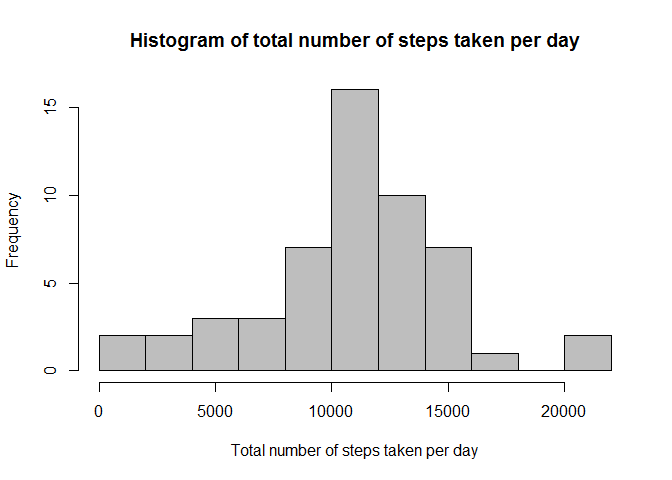

```r
noStepDay <- dataSet %>% group_by(date) %>% summarise(sum = sum(steps))
hist(noStepDay$sum, 15, col = "grey", main = "Histogram of total number of steps taken per day", xlab = "Total number of steps taken per day")
```

and the mean and median of the total number of steps per day are 10766 and 10765, respectively.

```r
summary(noStepDay$sum)
```

```
##    Min. 1st Qu.  Median    Mean 3rd Qu.    Max.    NA's
##      41    8841   10765   10766   13294   21194       8
```

## What is the average daily activity pattern?

Instead of grouping the data by date, it is now grouped by interval. In a similar way, after calling summarise function with mean, we get the mean of total number of steps per interval.

Note that the NA values are ignored.

Results are stored in *noStepItv* object, and a plot is generated to show the data

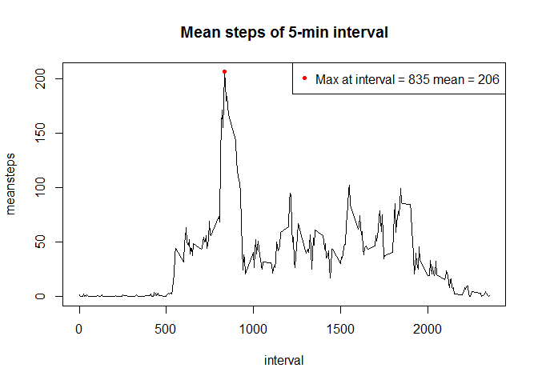

```r
noStepItv<- dataSet[!is.na(dataSet$steps),] %>% group_by(interval)%>% summarise(meansteps = mean(steps))
with(noStepItv, plot(interval, meansteps, type = "l", main = "Mean steps of 5-min interval") )
points(noStepItv[which.max(noStepItv$meansteps),], pch = 20, col = "red")
text1 <- paste0("Max at interval = ", as.character(noStepItv[which.max(noStepItv$meansteps),"interval"]))
text2 <- paste0("mean = ", as.character(round(noStepItv[which.max(noStepItv$meansteps),"meansteps"])))
text = paste(text1, text2, sep = " ")
legend("topright", pch = 20, legend = text, col = "red")
```

The **interval** that has the max mean steps is hilighted in the plot: at interval 835, with mean steps 206.